# Caduceus on Apple Silicon — research analysis

## 7. Performance: wall-clock vs sequence length

Sequential scan in `Mamba._ssm` dominates; per-position cost is roughly constant in `L`. Linear fit of total time vs. `L` gives the effective μs/position. Extrapolating to `L=131,072` gives the full pretrained-context forward time.

```python
def bench_forward(model, L, n_runs=3, n_warmup=1):
    rand_ids = torch.randint(7, 11, (1, L), dtype=torch.long, device=device)
    with torch.no_grad():
        for _ in range(n_warmup):
            _ = model(rand_ids)
    if device.type == "mps":
        torch.mps.synchronize()
    t0 = time.perf_counter()
    with torch.no_grad():
        for _ in range(n_runs):
            _ = model(rand_ids)
            if device.type == "mps":
                torch.mps.synchronize()
    return (time.perf_counter() - t0) / n_runs

lengths = [128, 256, 512, 1024, 2048, 4096]
times = [bench_forward(ph, L) for L in lengths]
for L, t in zip(lengths, times):
    print(f"L={L:>5d}: {t:>6.3f} s  ({t / L * 1e6:>6.1f} μs/pos)")

# Linear extrapolation to full pretrained context
slope, intercept = np.polyfit(lengths, times, 1)
L_full = 131072
print(f"\nlinear fit: {slope*1e6:.2f} μs/pos + {intercept*1e3:.1f} ms fixed")
print(f"extrapolated L=131,072: {slope*L_full + intercept:.0f} s ≈ {(slope*L_full + intercept)/60:.1f} min")
```

```
L=  128:  0.097 s  ( 757.7 μs/pos)
L=  256:  0.190 s  ( 743.3 μs/pos)
L=  512:  0.369 s  ( 719.7 μs/pos)
L= 1024:  0.734 s  ( 717.0 μs/pos)
L= 2048:  1.571 s  ( 767.0 μs/pos)
L= 4096:  3.030 s  ( 739.8 μs/pos)

linear fit: 744.28 μs/pos + -1.8 ms fixed
extrapolated L=131,072: 98 s ≈ 1.6 min
```

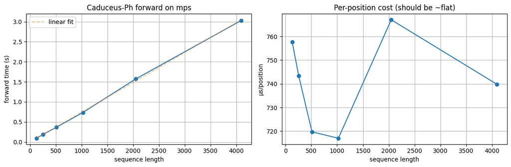

```python
fig, (ax1, ax2) = plt.subplots(1, 2, figsize=(12, 4))
ax1.plot(lengths, times, "o-")
ax1.plot(lengths, [slope*L + intercept for L in lengths], "--", alpha=0.5, label="linear fit")
ax1.set_xlabel("sequence length")
ax1.set_ylabel("forward time (s)")
ax1.set_title(f"Caduceus-Ph forward on {device}")
ax1.grid(True)
ax1.legend()

us_per_pos = [t / L * 1e6 for L, t in zip(lengths, times)]
ax2.plot(lengths, us_per_pos, "o-")
ax2.set_xlabel("sequence length")
ax2.set_ylabel("μs/position")
ax2.set_title("Per-position cost (should be ~flat)")
ax2.grid(True)
plt.tight_layout()
plt.show()
```

## 8. Memory profile

Per Mamba call, the largest live tensors are `deltaA` and `deltaB_u` of shape `(B, L, d_inner, n)`. Estimated peak working set as a function of `L`.

```
L=  1,024: ~ 0.16 GB peak (B=1, fp32)
L=  4,096: ~ 0.40 GB peak (B=1, fp32)
L= 16,384: ~ 1.37 GB peak (B=1, fp32)
L= 65,536: ~ 5.25 GB peak (B=1, fp32)
L=131,072: ~10.42 GB peak (B=1, fp32)
L=262,144: ~20.75 GB peak (B=1, fp32)
```

[figure not shown]

```python
d_inner = ph.caduceus.backbone.layers[0].mixer.mamba_fwd.d_inner  # 512
n_state = ph.caduceus.backbone.layers[0].mixer.mamba_fwd.A_log.shape[1]  # 16
d_model = ph.config.d_model  # 256

# Per-position memory cost (B=1, fp32):
#   deltaA + deltaB_u : 2 * d_inner * n_state * 4 bytes
#   Mamba transients  : ~5 * d_inner * 4   (xz, x, z, conv1d output, y)
#   Inter-layer state : ~3 * d_model * 4   (residual + hidden + 1 spare)
per_pos_bytes = 2 * d_inner * n_state * 4 + 5 * d_inner * 4 + 3 * d_model * 4
fixed_bytes = sum(p.numel() * 4 for p in {p.data_ptr(): p for p in ph.parameters()}.values()) + 50_000_000

lens = np.array([1024, 4096, 16384, 65536, 131072, 262144])
peak_gb = (per_pos_bytes * lens + fixed_bytes) / 1e9
for L, gb in zip(lens, peak_gb):
    print(f"L={L:>7,}: ~{gb:>5.2f} GB peak (B=1, fp32)")

plt.figure(figsize=(8, 4))
plt.plot(lens, peak_gb, "o-")
plt.axhline(8, color="orange", linestyle="--", label="8 GB Mac M-class budget (~)")
plt.axhline(16, color="red", linestyle="--", label="16 GB ceiling (~)")
plt.axhline(40, color="darkred", linestyle="--", label="48 GB realistic (~)")
plt.xlabel("sequence length")
plt.ylabel("estimated peak memory (GB)")
plt.title("Caduceus-Ph estimated memory vs L (B=1)")
plt.xscale("log")
plt.yscale("log")
plt.legend()
plt.grid(True, which="both", alpha=0.3)
plt.show()
```

## 9. Effective memory spectrum

For each `(channel, state-dim)` pair, the effective receptive field is `1 / (dt · |A|)`. We use `softplus(dt_proj.bias)` as the input-independent baseline (the actual `dt` is `softplus(W·x + bias)`, so this lower-bounds memory at typical inputs).

```python
def collect_effective_memories(model):
    layer_memories = []
    for layer in model.caduceus.backbone.layers:
        # rcps=False: layer.mixer is BiMambaWrapper. rcps=True: layer.mixer.submodule.
        mixer = layer.mixer
        if hasattr(mixer, "submodule"):
            mixer = mixer.submodule
        with torch.no_grad():
            mamba = mixer.mamba_fwd
            A = -torch.exp(mamba.A_log.float()).cpu()
            dt_baseline = F.softplus(mamba.dt_proj.bias.float()).cpu()
            mem = (1.0 / (dt_baseline.unsqueeze(-1) * A.abs())).flatten().numpy()
        layer_memories.append(mem)
    return layer_memories

ph_mems = collect_effective_memories(ph)
ps_mems = collect_effective_memories(ps)

ph_all = np.concatenate(ph_mems)
ps_all = np.concatenate(ps_mems)

for name, mem in [("Caduceus-Ph", ph_all), ("Caduceus-PS", ps_all)]:
    qs = np.quantile(mem, [0.1, 0.5, 0.9, 0.99])
    print(f"{name}: p10={qs[0]:6.1f} bp  p50={qs[1]:6.1f} bp  p90={qs[2]:7.1f} bp  p99={qs[3]:9.1f} bp  max={mem.max():.0f} bp")
```

```
Caduceus-Ph: p10=   0.3 bp  p50=   4.6 bp  p90=   88.4 bp  p99=   1211.6 bp  max=1326116 bp
Caduceus-PS: p10=   0.3 bp  p50=   5.1 bp  p90=   85.5 bp  p99=    929.9 bp  max=6235370 bp
```

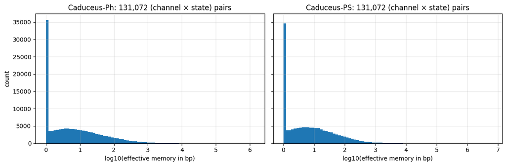

```python
fig, axes = plt.subplots(1, 2, figsize=(12, 4), sharey=True)
for ax, (name, mem) in zip(axes, [("Caduceus-Ph", ph_all), ("Caduceus-PS", ps_all)]):
    ax.hist(np.log10(np.maximum(mem, 1)), bins=80)
    ax.set_xlabel("log10(effective memory in bp)")
    ax.set_title(f"{name}: {len(mem):,} (channel × state) pairs")
    ax.grid(True, alpha=0.3)
axes[0].set_ylabel("count")
plt.tight_layout()
plt.show()
```

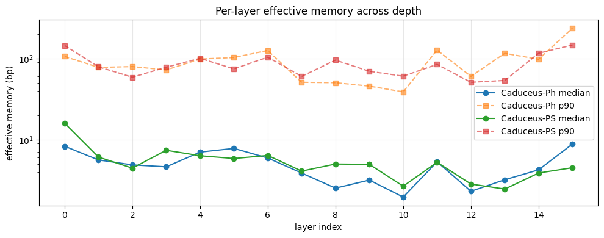

```python
# Per-layer median effective memory — does the model use shorter or longer scales at depth?
fig, ax = plt.subplots(figsize=(10, 4))
for name, mems in [("Caduceus-Ph", ph_mems), ("Caduceus-PS", ps_mems)]:
    medians = [np.median(m) for m in mems]
    p90s = [np.quantile(m, 0.9) for m in mems]
    ax.plot(medians, "o-", label=f"{name} median")
    ax.plot(p90s, "s--", alpha=0.6, label=f"{name} p90")
ax.set_xlabel("layer index")
ax.set_ylabel("effective memory (bp)")
ax.set_yscale("log")
ax.set_title("Per-layer effective memory across depth")
ax.legend()
ax.grid(True, alpha=0.3)
plt.tight_layout()
plt.show()
```

## 10. dt and A_log structure

`dt` is the discretization step; `A` is the diagonal SSM matrix (always negative). The product `dt · |A|` controls per-step decay. Visualizing these shows whether the model uses a uniform dynamics regime or learns specialized channels.

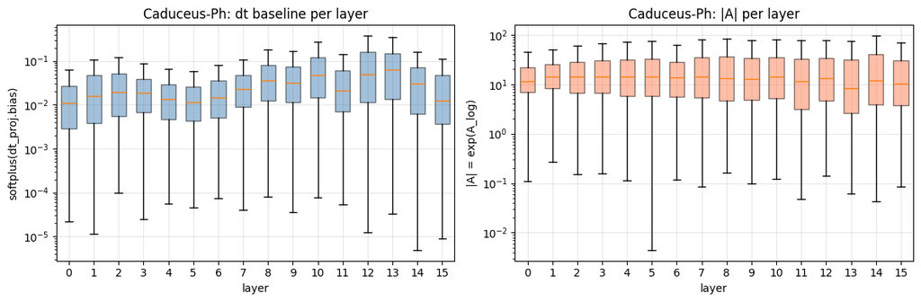

```python
fig, (ax1, ax2) = plt.subplots(1, 2, figsize=(12, 4))

# dt baseline distribution per layer
for layer_idx, layer in enumerate(ph.caduceus.backbone.layers):
    mixer = layer.mixer.submodule if hasattr(layer.mixer, "submodule") else layer.mixer
    with torch.no_grad():
        dt = F.softplus(mixer.mamba_fwd.dt_proj.bias.float()).cpu().numpy()
    bp = ax1.boxplot(dt, positions=[layer_idx], widths=0.6, showfliers=False, patch_artist=True)
    bp["boxes"][0].set_facecolor("steelblue")
    bp["boxes"][0].set_alpha(0.5)
ax1.set_xlabel("layer")
ax1.set_ylabel("softplus(dt_proj.bias)")
ax1.set_yscale("log")
ax1.set_title("Caduceus-Ph: dt baseline per layer")
ax1.grid(True, alpha=0.3)

# |A| distribution per layer
for layer_idx, layer in enumerate(ph.caduceus.backbone.layers):
    mixer = layer.mixer.submodule if hasattr(layer.mixer, "submodule") else layer.mixer
    with torch.no_grad():
        A = torch.exp(mixer.mamba_fwd.A_log.float()).cpu().numpy().flatten()
    bp = ax2.boxplot(A, positions=[layer_idx], widths=0.6, showfliers=False, patch_artist=True)
    bp["boxes"][0].set_facecolor("coral")
    bp["boxes"][0].set_alpha(0.5)
ax2.set_xlabel("layer")
ax2.set_ylabel("|A| = exp(A_log)")
ax2.set_yscale("log")
ax2.set_title("Caduceus-Ph: |A| per layer")
ax2.grid(True, alpha=0.3)

plt.tight_layout()
plt.show()
```

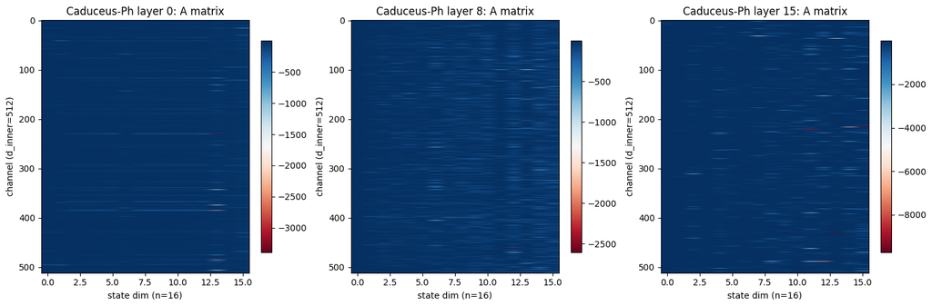

```python
# A_log heatmap for a few layers — visualizes the (d_inner, d_state) structure of the diagonal SSM matrix
fig, axes = plt.subplots(1, 3, figsize=(15, 5))
for ax, layer_idx in zip(axes, [0, 8, 15]):
    mixer = ph.caduceus.backbone.layers[layer_idx].mixer
    mixer = mixer.submodule if hasattr(mixer, "submodule") else mixer
    with torch.no_grad():
        A = -torch.exp(mixer.mamba_fwd.A_log.float()).cpu().numpy()
    im = ax.imshow(A, aspect="auto", cmap="RdBu")
    ax.set_xlabel("state dim (n=16)")
    ax.set_ylabel("channel (d_inner=512)")
    ax.set_title(f"Caduceus-Ph layer {layer_idx}: A matrix")
    plt.colorbar(im, ax=ax, fraction=0.046)
plt.tight_layout()
plt.show()
```

## 11. Activation sparsity & dead channels

Two views:

1. **Sparsity in the residual stream** at each layer (fraction of activations near zero) — useful for understanding where information lives.
2. **Dead channels in `A_log`**: very-large `|A|` × any `dt` ⇒ instant decay ⇒ channel doesn't carry information across positions. These channels are effectively local-only.

```
layer   h_abs_mean   h_near_zero_frac   r_abs_mean
    0       0.1346             0.0070       0.1406
    1       0.0920             0.0072       0.1224
    2       0.0941             0.0068       0.1519
    3       0.0811             0.0085       0.1831
    4       0.1021             0.0065       0.2039
    5       0.1103             0.0055       0.2360
    6       0.2038             0.0040       0.2629
    7       0.3435             0.0019       0.3791
    8       0.2937             0.0018       0.6009
    9       0.3914             0.0016       0.7592
   10       0.8122             0.0008       0.9244
   11       2.2958             0.0002       1.4183
   12       1.6704             0.0006       2.8727
   13       1.9076             0.0004       3.6061
   14       6.2528             0.0002       4.4958
   15      11.0548             0.0000       8.5214
```

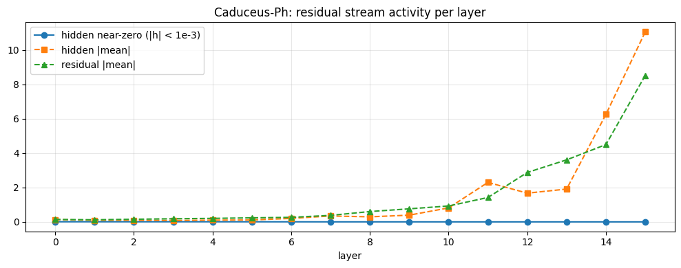

```python
# Capture residual stream sparsity per layer using a forward hook on each Block
stream_stats = []
hooks = []

def make_hook(layer_idx):
    def hook(module, inputs, outputs):
        # outputs is (hidden_states, residual)
        h, r = outputs
        stream_stats.append({
            "layer": layer_idx,
            "h_abs_mean": h.abs().mean().item(),
            "h_near_zero_frac": (h.abs() < 1e-3).float().mean().item(),
            "r_abs_mean": r.abs().mean().item(),
        })
    return hook

for i, layer in enumerate(ph.caduceus.backbone.layers):
    hooks.append(layer.register_forward_hook(make_hook(i)))

with torch.no_grad():
    _ = ph(ids)

for h in hooks:
    h.remove()

print(f"{'layer':>5} {'h_abs_mean':>12} {'h_near_zero_frac':>18} {'r_abs_mean':>12}")
for s in stream_stats:
    print(f"{s['layer']:>5d} {s['h_abs_mean']:>12.4f} {s['h_near_zero_frac']:>18.4f} {s['r_abs_mean']:>12.4f}")

layers_x = [s["layer"] for s in stream_stats]
fig, ax = plt.subplots(figsize=(10, 4))
ax.plot(layers_x, [s["h_near_zero_frac"] for s in stream_stats], "o-", label="hidden near-zero (|h| < 1e-3)")
ax.plot(layers_x, [s["h_abs_mean"] for s in stream_stats], "s--", label="hidden |mean|")
ax.plot(layers_x, [s["r_abs_mean"] for s in stream_stats], "^--", label="residual |mean|")
ax.set_xlabel("layer")
ax.set_title("Caduceus-Ph: residual stream activity per layer")
ax.legend()
ax.grid(True, alpha=0.3)
plt.tight_layout()
plt.show()
```

```python
# Dead channels: percent of (channel, state) pairs whose memory < 1 bp at typical dt baseline
for name, mems in [("Caduceus-Ph", ph_mems), ("Caduceus-PS", ps_mems)]:
    all_mem = np.concatenate(mems)
    dead_frac = (all_mem < 1.0).mean()
    very_long = (all_mem > 10000).mean()
    print(f"{name}: dead (<1 bp) = {dead_frac*100:5.1f}%   long-range (>10k bp) = {very_long*100:4.1f}%")
```

```
Caduceus-Ph: dead (<1 bp) =  24.7%   long-range (>10k bp) =  0.1%
Caduceus-PS: dead (<1 bp) =  23.7%   long-range (>10k bp) =  0.1%
```

## 12. RC equivariance verification (Caduceus-PS)

Architectural guarantee: `softmax(forward(x))[t, v] == softmax(forward(rc(x)))[L-1-t, complement(v)]`. Anything above ~1e-5 indicates a broken port (or numerical issue stacking up across 16 layers — which we already verified isn't the case).

```python
cmap = {int(k): v for k, v in ps.config.complement_map.items()}
rc_ids = torch.tensor([[cmap[t] for t in ids[0].tolist()][::-1]], dtype=torch.long).to(device)

with torch.no_grad():
    sm = F.softmax(ps(ids).logits, dim=-1)[0]
    sm_rc = F.softmax(ps(rc_ids).logits, dim=-1)[0]

cmap_idx = torch.tensor([cmap[i] for i in range(ps.config.vocab_size)], device=device)
sm_rc_aligned = torch.flip(sm_rc[..., cmap_idx], dims=[0])
diff = (sm - sm_rc_aligned).abs()

print(f"max abs diff in softmax: {diff.max().item():.2e}")
print(f"mean abs diff in softmax: {diff.mean().item():.2e}")
print(f"(architectural property; should be ~1e-5 or smaller on real weights)")
```

```
max abs diff in softmax: 8.94e-08
mean abs diff in softmax: 1.56e-09
(architectural property; should be ~1e-5 or smaller on real weights)
```

## 13. Suggested follow-ups

Things this notebook deliberately doesn't cover but are likely interesting:

- **Real biological accuracy**: replace the synthetic `seq` in Section 6 with held-out chromosome chunks (e.g., the Caduceus paper's evaluation regions on hg38). The methodology is identical; only the data source changes.
- **Mechanistic probing**: feed canonical motifs (TATA box, Kozak, splice sites) and look at which channels light up — pair with `forward_hook` on `mamba_fwd` per layer.
- **Embedding geometry**: PCA on the 16 token embeddings to see how the model represents nucleotides vs. special tokens; expect A/T and C/G to be related by the complement involution in PS.
- **Long-context probe**: run on a real chromosome chunk at L=131k and compare last-position embedding vs. windowed inference — quantifies how much long-range integration the trained channels actually do.
- **Effective rank of `x_proj`/`out_proj`**: SVD of the per-layer projections — if many singular values are ~zero, parts of the model are unused capacity.
- **Compare with sequential vs parallel scan** once Step 9 (log-space Heinsen) lands: same logits within fp32 tolerance, but multi-x speedup expected.
- **Sparsification studies**: prune the ~24% dead `(channel, state)` pairs and measure quality drop — the dt/A spectrum suggests substantial unused state-space capacity.
- **VEP variant scoring** as a downstream eval: uses the existing `vep_embeddings.py` pipeline ported to MPS as the consumer of this model.